# 如何在Rmarkdown中调用Python代码

邓旭东

7/26/2020

Python和R是一对数据科学两大语言，在互联互通的路上，我感觉R更加的积极。还记得之前 **Python中调用R的库-rpy2**， 在Python使用R语言语法还是有些不自然。在R中调用Python体验十分棒，一起跟我看看吧。

reticulate包是可以让R语言非常流畅自然联通Python的关键。

# 1 Rmarkdown预备知识

Rmarkdown很像jupyter notbeook和markdown的结合。

- 代码块
- markdon文本

## 1.1 代码块

在Rmarkdown中的代码块的开始都是以三引号、{}和语言名为标志，以三引号结尾。

```
library(ggplot2)
ggplot(mpg, aes(x=displ, y=cty))+
  geom_point()
```

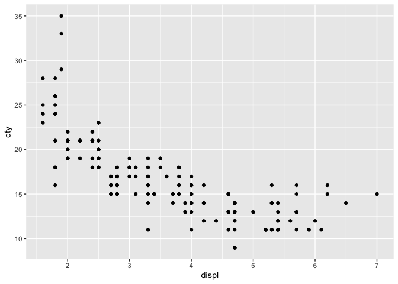

```r
library(ggplot2)
ggplot(mpg, aes(x=displ, y=cty))+
  geom_point()
```

后面设置好reticulate包后，就可以在Rmarkdown中使用python代码块，

```
import pandas as pd
df = pd.read_csv('test.csv')
df.head()
```

## 1.2 markdown文本

文本部分全部支持markdown语法，这里不做赘述。

# 2 安装

```
install.packages("reticulate")
```

# 3 环境设置

当我们在R代码块中设置好Python环境，就可以在Rmarkdown中跑Python代码。

## 3.1 查询Python

首先我们需要知道Python安装路径，可以在**命令行**中逐行执行下面代码

```
python3
import sys
sys.executable
```

我的mac电脑的Python安装路径为

```
/Library/Frameworks/Python.framework/Versions/3.7/bin/python3
```

## 3.2 指定Python

执行下方的代码(路径改为自己的Python安装路径)

```r
library(reticulate)
use_python('/Library/Frameworks/Python.framework/Versions/3.7/bin/python3')
```

执行代码后，我们就可以愉快的使用Python代码

# 4 运行Python代码

在Rmarkdown中写Python代码块

## 4.1 作图

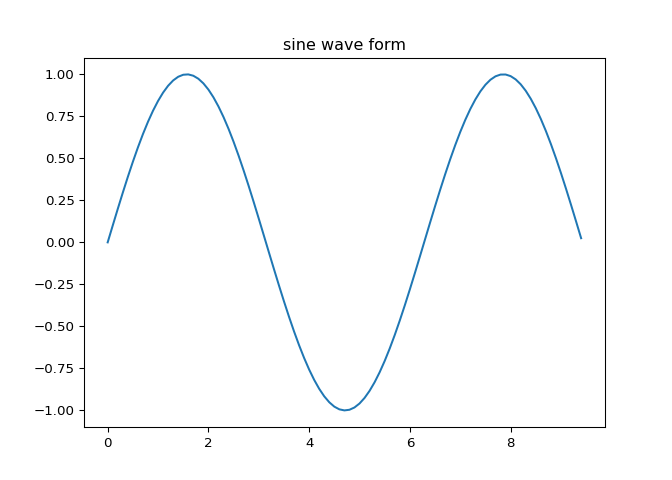

```python
import numpy as np
import matplotlib.pyplot as plt
# 计算正弦曲线上点的 x 和 y 坐标
x = np.arange(0,  3  * np.pi,  0.1)
y = np.sin(x)
plt.title("sine wave form")
# 使用 matplotlib 来绘制点
plt.plot(x, y)
plt.show()
```

## 4.2 读取csv

```python
import pandas as pd

df = pd.read_csv("test.csv", encoding="gbk")
df.head()
```

```
##      birthday   name               text  age  gender  height  weight
## 0  1985/10/08  Alice  我很开心，每天都这么快乐，我很幸福   35  female     175      55
## 1    95.07.07   Mary               我很难过   25  female     165      50
## 2    01-11-10   Mike              唉，真难受   19    male     180      75
## 3      90/2/8  Smith          无所谓开心还是难过   30    male     175      70
## 4      93-1-5  Henry          每天赚一万，真爽！   27    male     185      80
```

返回的df是Python对象，我们可以看到表格不好看，这是R中的Python对象。

# 5 在R代码块中调用Python变量(对象)

刚刚讲的都是在Rmakdown中运行Python代码块，并不是在R代码块中运行Python代码或者调用Python变量。

## 5.1 py$python_variable_name

R代码块中调用Python方法

py$python_variable_name

- py相当于Python中的对象
- $ 相当于Python中的**点**
- python_variable_name 是Python代码块中的变量名

比如在上文中Python的变量df，在R中调用

```r
py$df
```

| birthday | name | text | age | gender | height | weight |
| --- | --- | --- | --- | --- | --- | --- |
| 1985/10/08 | Alice | 我很开心，每天都这么快乐，我很幸福 | 35 | female | 175 | 55 |
| 95.07.07 | Mary | 我很难过 | 25 | female | 165 | 50 |
| 01-11-10 | Mike | 唉，真难受 | 19 | male | 180 | 75 |
| 90/2/8 | Smith | 无所谓开心还是难过 | 30 | male | 175 | 70 |
| 93-1-5 | Henry | 每天赚一万，真爽！ | 27 | male | 185 | 80 |
| 1988/2/9 | William | 爽歪歪 | 32 | male | 177 | 76 |
| 1986-03-21 | Will | 天气很凉爽，很舒服 | 34 | male | 180 | 85 |
| 1984.06.9 | Qunique | 每天开心 | 36 | female | 168 | 62 |
| 1993.07.09 | Sara | 难过悲伤 | 27 | female | 175 | 66 |
| 92/08/09 | Hillary | 美满幸福 | 28 | male | 190 | 85 |

现在调用Python对象df时，R会默认将其转为R对象，所以内容一样，样式似乎变好看了。

# 6 R代码块中导入Python库

使用os库的listdir函数查询当前项目文件夹内的文件列表

```python
import os

os.listdir()
```

```
## ['reticulate学习.md', 'test.csv', 'test.py', 'reticulate学习.html', 'reticulate学习_files', 'reticulate.pdf', 'reticulate学习.Rmd', 'data.py']
```

在R代码块中实现上方的Python功能，如下，很简单

```r
library(reticulate)

#导入库
os <- import("os")

#os库的listdir函数
os$listdir()
```

```
## [1] "reticulate学习.md"    "test.csv"             "test.py"
## [4] "reticulate学习.html"  "reticulate学习_files" "reticulate.pdf"
## [7] "reticulate学习.Rmd"   "data.py"
```

可以发现 - `import("os)`代替了`import os` - `$`代替了`.` - `<-` 代替了 `=`

再熟悉一下

```r
library(reticulate)
pd <- import("pandas")
df2 <- pd$read_csv("test.csv", encoding="gbk")
df2
```

| birthday | name | text | age | gender | height | weight |
| --- | --- | --- | --- | --- | --- | --- |
| 1985/10/08 | Alice | 我很开心，每天都这么快乐，我很幸福 | 35 | female | 175 | 55 |
| 95.07.07 | Mary | 我很难过 | 25 | female | 165 | 50 |
| 01-11-10 | Mike | 唉，真难受 | 19 | male | 180 | 75 |
| 90/2/8 | Smith | 无所谓开心还是难过 | 30 | male | 175 | 70 |
| 93-1-5 | Henry | 每天赚一万，真爽！ | 27 | male | 185 | 80 |
| 1988/2/9 | William | 爽歪歪 | 32 | male | 177 | 76 |
| 1986-03-21 | Will | 天气很凉爽，很舒服 | 34 | male | 180 | 85 |
| 1984.06.9 | Qunique | 每天开心 | 36 | female | 168 | 62 |
| 1993.07.09 | Sara | 难过悲伤 | 27 | female | 175 | 66 |
| 92/08/09 | Hillary | 美满幸福 | 28 | male | 190 | 85 |

需要注意的是，在R代码块中执行Python代码时，默认会将Python对象转为R对象。

## 6.1 source_python()

使用reticulate包中的source_python(‘py文件路径’)可以导入py文件中的变量，这样就可以在R代码块中使用外部变量。例如我在data.py中准备A和B两个字符串

```
A = '我是张三,'
B = '来自河北'
```

在R代码块中运行data.py

```r
library(reticulate)

source_python("data.py")
print(A)
```

```
## [1] "我是张三,"
```

```r
print(B)
```

```
## [1] "来自河北"
```

```r
paste0(A, B)
```

```
## [1] "我是张三,来自河北"
```

## 6.2 py_run_file()

在R代码块中运行项目文件夹中的test.py文件

```r
library(reticulate)
py_run_file("test.py")
```

# 7 数据类型对比

| R | Python | Examples |
| --- | --- | --- |
| Single-element vector | Scalar | `1`, `1L`, `TRUE`, `"foo"` |
| Multi-element vector | List | `c(1.0, 2.0, 3.0)`, `c(1L, 2L, 3L)` |
| List of multiple types | Tuple | `list(1L, TRUE, "foo")` |
| Named list | Dict | `list(a = 1L, b = 2.0)`, `dict(x = x_data)` |
| Matrix/Array | NumPy ndarray | `matrix(c(1,2,3,4), nrow = 2, ncol = 2)` |
| Data Frame | Pandas DataFrame | `data.frame(x = c(1,2,3), y = c("a", "b", "c"))` |
| Function | Python function | `function(x) x + 1` |
| NULL, TRUE, FALSE | None, True, False | `NULL`, `TRUE`, `FALSE` |